# Data Cleaning Process

## Managing outliers in the data

**‘Price’ variable** outliers detection:

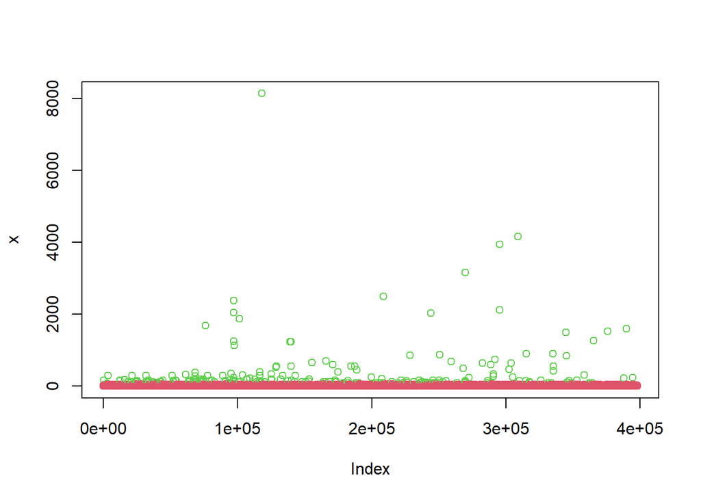

```r
x = online_retail_II$Price
t = 3
m = mean(x, na.rm = F)
s = sd(x, na.rm = F)
b1 = m-s*t
b2 = m+s*t
y = ifelse(x>= b1 & x<= b2, 0, 1)
#Plot for outliers detection of 'Price' variable
plot(x, col= y+2)
```

```r
#Possible outliers
outl = which(y==1)
online_retail_II[outl,]
```

```
## # A tibble: 221 x 12
##    Invoice StockCode Description Quantity InvoiceDate         Price CustomerID
##    <fct>   <fct>     <fct>          <int> <dttm>              <dbl> <fct>
##  1 536392  22827     RUSTIC  SE~        1 2010-12-01 10:29:00 165   13705
##  2 536676  21769     VINTAGE PO~        1 2010-12-02 12:18:00  80.0 16752
##  3 536835  22655     VINTAGE RE~        1 2010-12-02 18:06:00 295   13145
##  4 537859  22828     REGENCY MI~        1 2010-12-08 16:11:00 165   14030
##  5 537859  22827     RUSTIC  SE~        2 2010-12-08 16:11:00 145   14030
##  6 538354  22826     LOVE SEAT ~        2 2010-12-10 15:45:00 175   16873
##  7 538662  22655     VINTAGE RE~        2 2010-12-13 15:44:00 125   15159
##  8 538662  22656     VINTAGE BL~        2 2010-12-13 15:44:00 125   15159
##  9 538999  22655     VINTAGE RE~        2 2010-12-15 12:09:00 125   16003
## 10 538999  22656     VINTAGE BL~        2 2010-12-15 12:09:00 125   16003
## # ... with 211 more rows, and 5 more variables: Country <fct>,
## #   Amount_spent <dbl>, Day_of_the_week <fct>, Month_Yr <fct>, Hour <fct>
```

**‘Quantity’ variable** outliers detection:

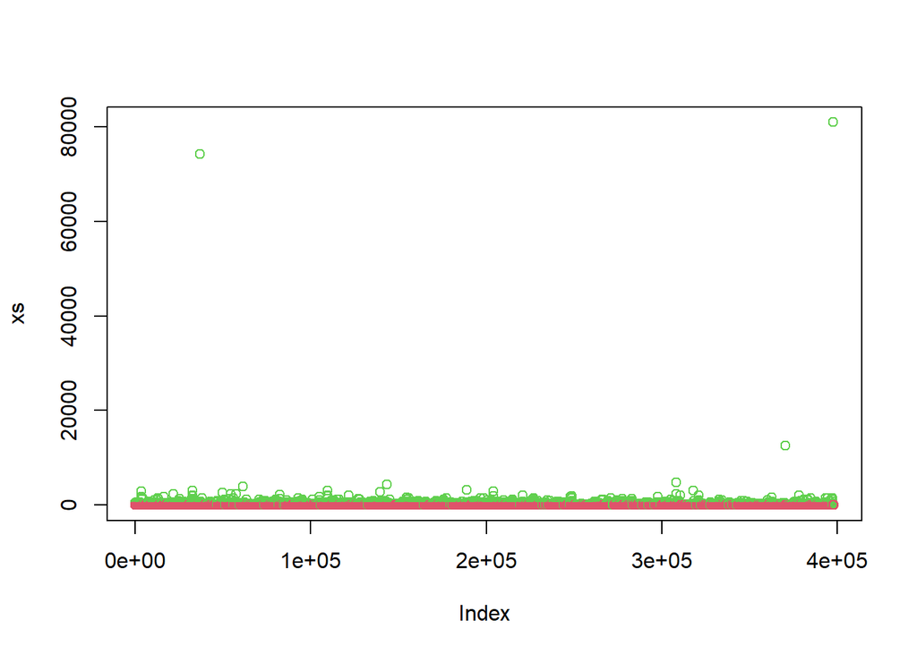

```r
xs = online_retail_II$Quantity
ts = 3
ms = mean(x,na.rm = F)
ss = sd(x, na.rm = F)
b1s = ms - ss*ts
b2s = ms + ss*ts
ys = ifelse(xs>= b1s & xs<= b2s, 0,1)
#Plot for outliers detection of 'Quantity' variable
plot(xs,col= ys+2)
```

```r
#Possible outliers
outls = which(ys==1)
online_retail_II[outls,]
```

```
## # A tibble: 10,594 x 12
##    Invoice StockCode Description Quantity InvoiceDate         Price CustomerID
##    <fct>   <fct>     <fct>          <int> <dttm>              <dbl> <fct>
##  1 536371  22086     PAPER CHAI~       80 2010-12-01 09:00:00  2.55 13748
##  2 536378  21212     PACK OF 72~      120 2010-12-01 09:37:00  0.42 14688
##  3 536378  85071B    RED CHARLI~       96 2010-12-01 09:37:00  0.38 14688
##  4 536386  85099C    JUMBO  BAG~      100 2010-12-01 09:57:00  1.65 16029
##  5 536386  85099B    JUMBO BAG ~      100 2010-12-01 09:57:00  1.65 16029
##  6 536387  79321     CHILLI LIG~      192 2010-12-01 09:58:00  3.82 16029
##  7 536387  22780     LIGHT GARL~      192 2010-12-01 09:58:00  3.37 16029
##  8 536387  22779     WOODEN OWL~      192 2010-12-01 09:58:00  3.37 16029
##  9 536387  22466     FAIRY TALE~      432 2010-12-01 09:58:00  1.45 16029
## 10 536387  21731     RED TOADST~      432 2010-12-01 09:58:00  1.25 16029
## # ... with 10,584 more rows, and 5 more variables: Country <fct>,
## #   Amount_spent <dbl>, Day_of_the_week <fct>, Month_Yr <fct>, Hour <fct>
```

There are 221 possible outliers for ‘Price’ variable and 10,594 possible outliers for ‘Quantity’ in the dataset. However, considering the characters of the e-commerce dataset, it’s possible that there were customers ordered a huge quantity of products and there were also possible expensive products. Therefore, this report didn’t exclude the possible outliers

## Plausibility check for Factor and Date-time variables

This step is to detect any invalid values of Factor and Date-time variables using *summary()* function.

```r
summary(online_retail_II)
```

```
##     Invoice         StockCode                                  Description
##  576339 :   542   85123A :  2035   WHITE HANGING HEART T-LIGHT HOLDER:  2028
##  579196 :   533   22423  :  1724   REGENCY CAKESTAND 3 TIER          :  1724
##  580727 :   529   85099B :  1618   JUMBO BAG RED RETROSPOT           :  1618
##  578270 :   442   84879  :  1408   ASSORTED COLOUR BIRD ORNAMENT     :  1408
##  573576 :   435   47566  :  1397   PARTY BUNTING                     :  1397
##  567656 :   421   20725  :  1317   LUNCH BAG RED RETROSPOT           :  1316
##  (Other):395023   (Other):388426   (Other)                           :388434
##     Quantity         InvoiceDate                      Price
##  Min.   :    1.00   Min.   :2010-12-01 08:26:00   Min.   :   0.000
##  1st Qu.:    2.00   1st Qu.:2011-04-07 11:12:00   1st Qu.:   1.250
##  Median :    6.00   Median :2011-07-31 14:39:00   Median :   1.950
##  Mean   :   13.02   Mean   :2011-07-10 23:44:09   Mean   :   3.116
##  3rd Qu.:   12.00   3rd Qu.:2011-10-20 14:33:00   3rd Qu.:   3.750
##  Max.   :80995.00   Max.   :2011-12-09 12:50:00   Max.   :8142.750
##
##    CustomerID               Country        Amount_spent        Day_of_the_week
##  17841  :  7847   United Kingdom:354345   Min.   :     0.00   Friday   :54835
##  14911  :  5677   Germany       :  9042   1st Qu.:     4.68   Monday   :64899
##  14096  :  5111   France        :  8343   Median :    11.80   Sunday   :62775
##  12748  :  4596   EIRE          :  7238   Mean   :    22.39   Thursday :80052
##  14606  :  2700   Spain         :  2485   3rd Qu.:    19.80   Tuesday  :66476
##  15311  :  2379   Netherlands   :  2363   Max.   :168469.60   Wednesday:68888
##  (Other):369615   (Other)       : 14109
##     Month_Yr           Hour
##  2011-11: 64545   12     :72070
##  2011-10: 49557   13     :64031
##  2011-09: 40030   14     :54127
##  2011-05: 28322   11     :49092
##  2011-06: 27185   15     :45372
##  2011-03: 27177   10     :37999
##  (Other):161109   (Other):75234
```

There is no invalid factor or date-time values detected from the dataset.